# kpmg_data_insights-real

```python
# import all packages and set plots to be embedded inline
import numpy as np
import pandas as pd
import matplotlib.pyplot as plt
import seaborn as sb
import math
plt.rc("font", size=14)
from sklearn.linear_model import LogisticRegression
from sklearn.model_selection import train_test_split

%matplotlib inline
```

## OLD SPROCKET LTD PTY CUSTOMERS

```python
kpmg=pd.read_csv('kpmg_data.csv')
kpmg.head(8)
```

|  | transaction_id | product_id | customer_id | recency | transaction_date | transaction_month | online_order | order_status | brand | product_line | ... | job_industry_category | wealth_segment | deceased_indicator | owns_car | tenure | address | postcode | state | country | property_valuation |
| --- | --- | --- | --- | --- | --- | --- | --- | --- | --- | --- | --- | --- | --- | --- | --- | --- | --- | --- | --- | --- | --- |
| 0 | 253 | 2 | 3123 | 0 | 12/30/2017 | December | False | Approved | Giant Bicycles | Road | ... | Health | Mass Customer | N | Yes | 1 | 6915 Nobel Crossing | 2195 | NSW | Australia | 6 |
| 1 | 411 | 62 | 3355 | 0 | 12/30/2017 | December | False | Approved | Solex | Standard | ... | Health | Mass Customer | N | Yes | 1 | 45 Talisman Pass | 4102 | QLD | Australia | 4 |
| 2 | 497 | 62 | 1854 | 0 | 12/30/2017 | December | True | Approved | Solex | Standard | ... | Manufacturing | High Net Worth | N | No | 12 | 48023 International Way | 3630 | VIC | Australia | 1 |
| 3 | 606 | 70 | 2878 | 0 | 12/30/2017 | December | False | Approved | Trek Bicycles | Standard | ... | Health | Mass Customer | N | Yes | 1 | 12574 Truax Alley | 2316 | NSW | Australia | 6 |
| 4 | 748 | 80 | 2865 | 0 | 12/30/2017 | December | True | Approved | Trek Bicycles | Standard | ... | Health | Mass Customer | N | Yes | 1 | 6804 Red Cloud Parkway | 2099 | NSW | Australia | 9 |
| 5 | 1697 | 56 | 2421 | 0 | 12/30/2017 | December | True | Approved | OHM Cycles | Standard | ... | Manufacturing | High Net Worth | N | Yes | 3 | 1369 Morrow Plaza | 3046 | VIC | Australia | 8 |
| 6 | 2285 | 95 | 3216 | 0 | 12/30/2017 | December | True | Approved | Giant Bicycles | Standard | ... | Health | Mass Customer | N | Yes | 1 | 26710 Express Trail | 4390 | QLD | Australia | 7 |
| 7 | 2843 | 90 | 1506 | 0 | 12/30/2017 | December | True | Approved | Norco Bicycles | Standard | ... | Manufacturing | High Net Worth | N | No | 12 | 6 Canary Plaza | 2223 | NSW | Australia | 8 |

8 rows × 31 columns

```python
#1 Checking the dimension of the kpmg dataframe
kpmg.shape
```

```
(16826, 31)
```

```python
#2 Checking the data structure and also if there is missing value in any row in the data frame
kpmg.info()
```

```
<class 'pandas.core.frame.DataFrame'>
RangeIndex: 16826 entries, 0 to 16825
Data columns (total 31 columns):
transaction_id                         16826 non-null int64
product_id                             16826 non-null int64
customer_id                            16826 non-null int64
recency                                16826 non-null int64
transaction_date                       16826 non-null object
transaction_month                      16826 non-null object
online_order                           16826 non-null bool
order_status                           16826 non-null object
brand                                  16826 non-null object
product_line                           16826 non-null object
product_class                          16826 non-null object
product_size                           16826 non-null object
list_price                             16826 non-null float64
standard_cost                          16826 non-null float64
product_first_sold_date                16826 non-null object
profit                                 16826 non-null float64
gender                                 16826 non-null object
past_3_years_bike_related_purchases    16826 non-null int64
dob                                    16826 non-null object
age                                    16826 non-null float64
job_title                              16826 non-null object
job_industry_category                  16826 non-null object
wealth_segment                         16826 non-null object
deceased_indicator                     16826 non-null object
owns_car                               16826 non-null object
tenure                                 16826 non-null int64
address                                16826 non-null object
postcode                               16826 non-null int64
state                                  16826 non-null object
country                                16826 non-null object
property_valuation                     16826 non-null int64
dtypes: bool(1), float64(4), int64(8), object(18)
memory usage: 3.9+ MB
```

```python
#missing data
total = kpmg.isnull().sum().sort_values(ascending=False)
percent = (kpmg.isnull().sum()/kpmg.isnull().count()).sort_values(ascending=False)
missing_data = pd.concat([total, percent], axis=1, keys=['Total', 'Percent'])
missing_data
```

|  | Total | Percent |
| --- | --- | --- |
| property_valuation | 0 | 0.0 |
| product_first_sold_date | 0 | 0.0 |
| product_id | 0 | 0.0 |
| customer_id | 0 | 0.0 |
| recency | 0 | 0.0 |
| transaction_date | 0 | 0.0 |
| transaction_month | 0 | 0.0 |
| online_order | 0 | 0.0 |
| order_status | 0 | 0.0 |
| brand | 0 | 0.0 |
| product_line | 0 | 0.0 |
| product_class | 0 | 0.0 |
| product_size | 0 | 0.0 |
| list_price | 0 | 0.0 |
| standard_cost | 0 | 0.0 |
| profit | 0 | 0.0 |
| country | 0 | 0.0 |
| gender | 0 | 0.0 |
| past_3_years_bike_related_purchases | 0 | 0.0 |
| dob | 0 | 0.0 |
| age | 0 | 0.0 |
| job_title | 0 | 0.0 |
| job_industry_category | 0 | 0.0 |
| wealth_segment | 0 | 0.0 |
| deceased_indicator | 0 | 0.0 |
| owns_car | 0 | 0.0 |
| tenure | 0 | 0.0 |
| address | 0 | 0.0 |
| postcode | 0 | 0.0 |
| state | 0 | 0.0 |
| transaction_id | 0 | 0.0 |

```python
kpmg['transaction_date']=pd.to_datetime(kpmg['transaction_date'])
```

```python
kpmg.order_status=kpmg.order_status.astype('category')
```

```python
kpmg.brand=kpmg.brand.astype('category')
```

```python
kpmg.product_line=kpmg.product_line.astype('category')
```

```python
kpmg.product_class=kpmg.product_class.astype('category')
```

```python
kpmg.product_size=kpmg.product_size.astype('category')
```

```python
kpmg.gender=kpmg.gender.astype('category')
```

```python
kpmg['product_first_sold_date']=pd.to_datetime(kpmg['product_first_sold_date'])
```

```python
kpmg.job_title=kpmg.job_title.astype('category')
```

```python
kpmg.job_industry_category=kpmg.job_industry_category.astype('category')
```

```python
kpmg.wealth_segment=kpmg.wealth_segment.astype('category')
```

```python
kpmg.owns_car=kpmg.owns_car.astype('category')
```

```python
kpmg.dtypes
```

```
transaction_id                                  int64
product_id                                      int64
customer_id                                     int64
recency                                         int64
transaction_date                       datetime64[ns]
transaction_month                              object
online_order                                     bool
order_status                                 category
brand                                        category
product_line                                 category
product_class                                category
product_size                                 category
list_price                                    float64
standard_cost                                 float64
product_first_sold_date                datetime64[ns]
profit                                        float64
gender                                       category
past_3_years_bike_related_purchases             int64
dob                                            object
age                                           float64
job_title                                    category
job_industry_category                        category
wealth_segment                               category
deceased_indicator                             object
owns_car                                     category
tenure                                          int64
address                                        object
postcode                                        int64
state                                          object
country                                        object
property_valuation                              int64
dtype: object
```

```python
kpmg.describe()
```

|  | transaction_id | product_id | customer_id | recency | list_price | standard_cost | profit | past_3_years_bike_related_purchases | age | tenure | postcode | property_valuation |
| --- | --- | --- | --- | --- | --- | --- | --- | --- | --- | --- | --- | --- |
| count | 16826.000000 | 16826.000000 | 16826.000000 | 16826.000000 | 16826.000000 | 16826.000000 | 16826.000000 | 16826.000000 | 16826.000000 | 16826.000000 | 16826.000000 | 16826.000000 |
| mean | 10000.197551 | 45.838227 | 1897.885415 | 181.129977 | 1110.190562 | 556.247939 | 553.942622 | 46.916023 | 42.159294 | 7.277784 | 2990.389100 | 7.512837 |
| std | 5793.577815 | 30.600867 | 994.676856 | 105.411954 | 580.868041 | 404.975955 | 492.668851 | 27.653054 | 19.936642 | 4.869797 | 850.398442 | 2.834700 |
| min | 1.000000 | 0.000000 | 1.000000 | 0.000000 | 12.010000 | 7.210000 | 4.800000 | 13.000000 | 18.581720 | 0.000000 | 2000.000000 | 1.000000 |
| 25% | 4959.250000 | 18.000000 | 1212.000000 | 89.000000 | 586.450000 | 215.140000 | 135.850000 | 16.000000 | 18.581720 | 1.000000 | 2200.000000 | 6.000000 |
| 50% | 10024.500000 | 45.000000 | 1970.500000 | 180.000000 | 1163.890000 | 507.580000 | 445.210000 | 62.000000 | 59.137884 | 11.000000 | 2769.000000 | 8.000000 |
| 75% | 15037.750000 | 73.000000 | 2728.000000 | 272.000000 | 1635.300000 | 795.100000 | 830.240000 | 67.000000 | 59.137884 | 12.000000 | 3756.000000 | 10.000000 |
| max | 20000.000000 | 100.000000 | 3500.000000 | 363.000000 | 2091.470000 | 1759.850000 | 1702.550000 | 93.000000 | 120.724186 | 13.000000 | 4883.000000 | 12.000000 |

```python
#I am converting numerical variable to categorical variable using pandas' cut function
kpmg['ageGroup']=pd.cut(kpmg.age,[18,25,35,60,125],labels=['young adults', 'adults', 'middle aged', 'old adults'])
kpmg['ageGroup'].head()
```

```
0    young adults
1    young adults
2     middle aged
3    young adults
4    young adults
Name: ageGroup, dtype: category
Categories (4, object): [young adults < adults < middle aged < old adults]
```

```python
#Checking the overall counts of customers age categorising them into age groups in the dataset
pd.DataFrame(kpmg.ageGroup.value_counts())
```

|  | ageGroup |
| --- | --- |
| middle aged | 5848 |
| young adults | 5039 |
| adults | 3201 |
| old adults | 2738 |

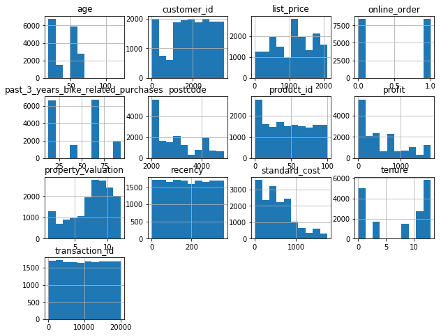

```python
#checking histogram of entite kpmg dataset
kpmg.hist(figsize=(10,8));
```

**BAR CHART OF QUALITATIVE VARIABLE IN THE DATASET**

```python
#Checking the overall counts of customers age categorising them into age groups in the dataset
pd.DataFrame(kpmg.ageGroup.value_counts())
```

|  | ageGroup |
| --- | --- |
| middle aged | 5848 |
| young adults | 5039 |
| adults | 3201 |
| old adults | 2738 |

```python
kpmg.ageGroup=kpmg.ageGroup.astype('category')
```

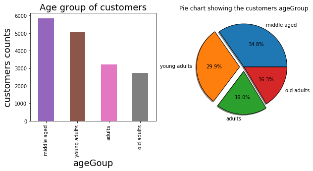

```python
#Plotting the age Group on a bar chart
plt.figure(figsize=(10,4))
plt.subplot(1,2,1);
kpmg.ageGroup.value_counts().plot(kind='bar',color=['C4','C5','C6','C7']);
plt.title('Age group of customers',fontsize=18)
plt.xlabel('ageGoup',fontsize=18)
plt.ylabel('customers counts',fontsize=18);

plt.subplot(1,2,2);
ageGroup_values=[5848,5039,3201,2738]
ageGroup_labels=["middle aged","young adults","adults","old adults"]
plt.axis("equal")
plt.title("Pie chart showing the customers ageGroup")
plt.pie(ageGroup_values,labels=ageGroup_labels,radius=1.0,autopct='%0.1f%%',shadow=True,explode=[0,0.1,0.1,0],wedgeprops={'edgecolor':'black'});
```

```python
#Checking number of customers wealth in the kpmg dataset
pd.DataFrame(kpmg.owns_car.value_counts())
```

|  | owns_car |
| --- | --- |
| Yes | 10969 |
| No | 5857 |

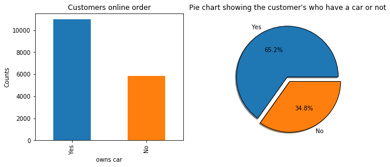

```python
plt.figure(figsize=(10,4))
plt.subplot(1,2,1)
kpmg.owns_car.value_counts().plot(kind='bar',title='Customers online order',color=['C0','C1']);
plt.xlabel('owns car')
plt.ylabel('Counts');

plt.subplot(1,2,2)
order_values=[10969,5857]
order_labels=["Yes","No"]
plt.axis("equal")
plt.title("Pie chart showing the customer's who have a car or not")
plt.pie(order_values,labels=order_labels,radius=1.0,autopct='%0.1f%%',shadow=True,explode=[0,0.1],wedgeprops={'edgecolor':'black'});
```

```python
#Checking number of customers that made an online order in the kpmg dataset
pd.DataFrame(kpmg.online_order.value_counts())
```

|  | online_order |
| --- | --- |
| False | 8422 |
| True | 8404 |

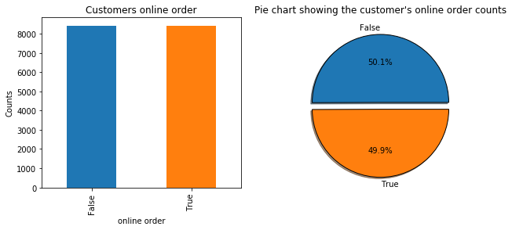

```python
plt.figure(figsize=(10,4))
plt.subplot(1,2,1)
kpmg.online_order.value_counts().plot(kind='bar',title='Customers online order',color=['C0','C1']);
plt.xlabel('online order')
plt.ylabel('Counts');

plt.subplot(1,2,2)
order_values=[8422,8404]
order_labels=["False","True"]
plt.axis("equal")
plt.title("Pie chart showing the customer's online order counts")
plt.pie(order_values,labels=order_labels,radius=1.0,autopct='%0.1f%%',shadow=True,explode=[0,0.1],wedgeprops={'edgecolor':'black'});
```

```python
#Checking number of customers that made have their order approved or not in the kpmg dataset
pd.DataFrame(kpmg.order_status.value_counts())
```

|  | order_status |
| --- | --- |
| Approved | 16673 |
| Cancelled | 153 |

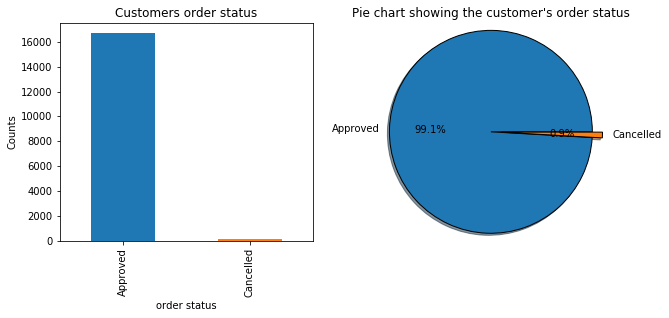

```python
plt.figure(figsize=(10,4))
plt.subplot(1,2,1)
kpmg.order_status.value_counts().plot(kind='bar',title='Customers order status',color=['C0','C1']);
plt.xlabel('order status')
plt.ylabel('Counts');

plt.subplot(1,2,2)
order_values=[16673,153]
order_labels=["Approved","Cancelled"]
plt.axis("equal")
plt.title("Pie chart showing the customer's order status")
plt.pie(order_values,labels=order_labels,radius=1.0,autopct='%0.1f%%',shadow=True,explode=[0,0.1],wedgeprops={'edgecolor':'black'});
```

```python
#Checking number of customers that made an online order in the kpmg dataset
pd.DataFrame(kpmg.brand.value_counts())
```

|  | brand |
| --- | --- |
| Solex | 3607 |
| WeareA2B | 2834 |
| Giant Bicycles | 2814 |
| OHM Cycles | 2586 |
| Trek Bicycles | 2533 |
| Norco Bicycles | 2452 |

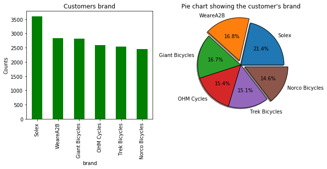

```python
plt.figure(figsize=(10,4))
plt.subplot(1,2,1)
kpmg.brand.value_counts().plot(kind='bar',title='Customers brand',color=['green']);
plt.xlabel('brand')
plt.ylabel('Counts');

plt.subplot(1,2,2)
brand_values=[3607,2834,2814,2586,2533,2452]
brand_labels=["Solex","WeareA2B","Giant Bicycles","OHM Cycles","Trek Bicycles","Norco Bicycles"]
plt.axis("equal")
plt.title("Pie chart showing the customer's brand")
plt.pie(brand_values,labels=brand_labels,radius=1.0,autopct='%0.1f%%',shadow=True,explode=[0,0.1,0,0,0,0.1],wedgeprops={'edgecolor':'black'});
```

```python
#Checking number of customers product line in the kpmg dataset
pd.DataFrame(kpmg.product_line.value_counts())
```

|  | product_line |
| --- | --- |
| Standard | 12045 |
| Road | 3350 |
| Touring | 1062 |
| Mountain | 369 |

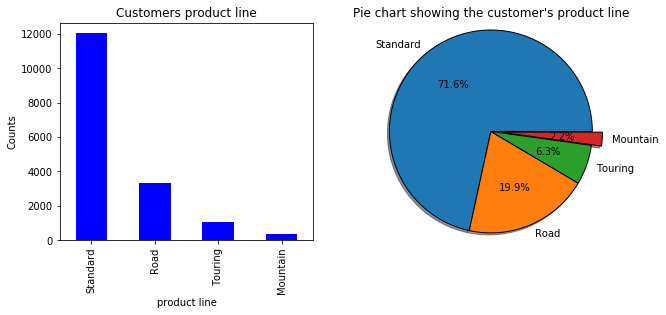

```python
plt.figure(figsize=(10,4))
plt.subplot(1,2,1)
kpmg.product_line.value_counts().plot(kind='bar',title='Customers product line',color=['blue']);
plt.xlabel('product line')
plt.ylabel('Counts');

plt.subplot(1,2,2)
pline_values=[12045,3350,1062,369]
pline_labels=["Standard","Road","Touring","Mountain"]
plt.axis("equal")
plt.title("Pie chart showing the customer's product line")
plt.pie(pline_values,labels=pline_labels,radius=1.0,autopct='%0.1f%%',shadow=True,explode=[0,0,0,0.1],wedgeprops={'edgecolor':'black'});
```

```python
#Checking number of customers product class in the kpmg dataset
pd.DataFrame(kpmg.product_class.value_counts())
```

|  | product_class |
| --- | --- |
| medium | 11747 |
| high | 2554 |
| low | 2525 |

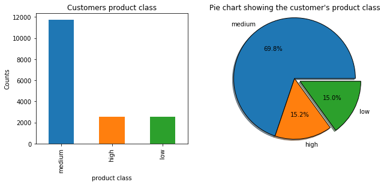

```python
plt.figure(figsize=(10,4))
plt.subplot(1,2,1)
kpmg.product_class.value_counts().plot(kind='bar',title='Customers product class',color=['C0','C1','C2']);
plt.xlabel('product class')
plt.ylabel('Counts');

plt.subplot(1,2,2)
pclass_values=[11747,2554,2525]
pclass_labels=["medium","high","low"]
plt.axis("equal")
plt.title("Pie chart showing the customer's product class")
plt.pie(pclass_values,labels=pclass_labels,radius=1.0,autopct='%0.1f%%',shadow=True,explode=[0,0,0.1],wedgeprops={'edgecolor':'black'});
```

```python
#Checking number of customers product size in the kpmg dataset
pd.DataFrame(kpmg.product_size.value_counts())
```

|  | product_size |
| --- | --- |
| medium | 11057 |
| large | 3378 |
| small | 2391 |

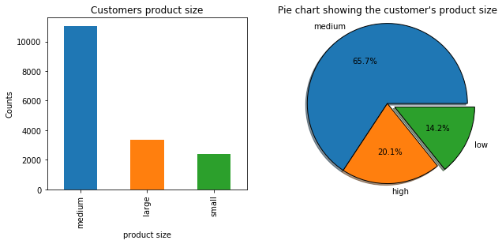

```python
plt.figure(figsize=(10,4))
plt.subplot(1,2,1)
kpmg.product_size.value_counts().plot(kind='bar',title='Customers product size',color=['C0','C1','C2']);
plt.xlabel('product size')
plt.ylabel('Counts');

plt.subplot(1,2,2)
psize_values=[11057,3378,2391]
psize_labels=["medium","high","low"]
plt.axis("equal")
plt.title("Pie chart showing the customer's product size")
plt.pie(psize_values,labels=psize_labels,radius=1.0,autopct='%0.1f%%',shadow=True,explode=[0,0,0.1],wedgeprops={'edgecolor':'black'});
```

```python
#Checking number of customers gender in the kpmg dataset
pd.DataFrame(kpmg.gender.value_counts())
```

|  | gender |
| --- | --- |
| Female | 16022 |
| Male | 801 |
| U | 3 |

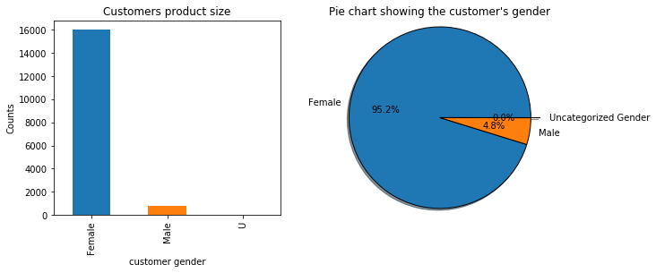

```python
plt.figure(figsize=(10,4))
plt.subplot(1,2,1)
kpmg.gender.value_counts().plot(kind='bar',title='Customers product size',color=['C0','C1','C2']);
plt.xlabel('customer gender')
plt.ylabel('Counts');

plt.subplot(1,2,2)
psize_values=[16022,801,3]
psize_labels=["Female","Male","Uncategorized Gender"]
plt.axis("equal")
plt.title("Pie chart showing the customer's gender")
plt.pie(psize_values,labels=psize_labels,radius=1.0,autopct='%0.1f%%',shadow=True,explode=[0,0,0.1],wedgeprops={'edgecolor':'black'});
```

```python
#Checking number of customers jobs in the kpmg dataset
pd.DataFrame(kpmg.job_title.value_counts())
```

|  | job_title |
| --- | --- |
| Research Associate | 5840 |
| Food Chemist | 5039 |
| Executive Secretary | 1933 |
| Payment Adjustment Coordinator | 1694 |
| Internal Auditor | 1501 |
| Operator | 793 |
| Recruiter | 9 |
| Speech Pathologist | 8 |
| Human Resources Assistant II | 6 |
| Assistant Professor | 3 |

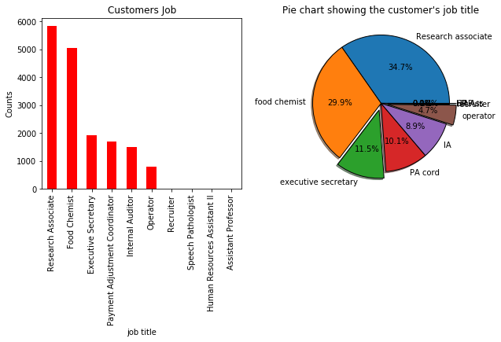

```python
plt.figure(figsize=(10,4))
plt.subplot(1,2,1)
kpmg.job_title.value_counts().plot(kind='bar',title='Customers Job',color=['red']);
plt.xlabel('job title')
plt.ylabel('Counts');

plt.subplot(1,2,2)
jt_values=[5840,5039,1933,1694,1501,793,9,8,6,3]
jt_labels=["Research associate","food chemist","executive secretary","PA cord","IA","operator","recruiter","SP","HR Ass","AP"]
plt.axis("equal")
plt.title("Pie chart showing the customer's job title")
plt.pie(jt_values,labels=jt_labels,radius=1.0,autopct='%0.1f%%',shadow=True,explode=[0,0,0.1,0,0,0.1,0,0,0,0.1],wedgeprops={'edgecolor':'black'});
```

```python
#Checking number of customers industry in the kpmg dataset
pd.DataFrame(kpmg.job_industry_category.value_counts())
```

|  | job_industry_category |
| --- | --- |
| Manufacturing | 7534 |
| Health | 6972 |
| Financial Services | 1515 |
| Argiculture | 793 |
| Property | 9 |
| IT | 3 |

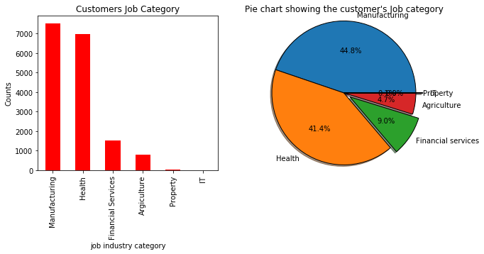

```python
plt.figure(figsize=(10,4))
plt.subplot(1,2,1)
kpmg.job_industry_category.value_counts().plot(kind='bar',title='Customers Job Category',color=['red']);
plt.xlabel('job industry category')
plt.ylabel('Counts');

plt.subplot(1,2,2)
ji_values=[7534,6972,1515,793,9,3]
ji_labels=["Manufacturing","Health","Financial services","Agriculture","Property","IT"]
plt.axis("equal")
plt.title("Pie chart showing the customer's Job category")
plt.pie(ji_values,labels=ji_labels,radius=1.0,autopct='%0.1f%%',shadow=True,explode=[0,0,0.1,0,0,0.1],wedgeprops={'edgecolor':'black'});
```

```python
#Checking number of customers wealth in the kpmg dataset
pd.DataFrame(kpmg.wealth_segment.value_counts())
```

|  | wealth_segment |
| --- | --- |
| Mass Customer | 9266 |
| High Net Worth | 7551 |
| Affluent Customer | 9 |

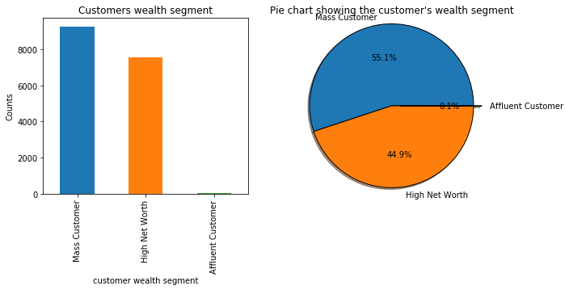

```python
plt.figure(figsize=(10,4))
plt.subplot(1,2,1)
kpmg.wealth_segment.value_counts().plot(kind='bar',title='Customers wealth segment',color=['C0','C1','C2']);
plt.xlabel('customer wealth segment')
plt.ylabel('Counts');

plt.subplot(1,2,2)
wealth_values=[9266,7551,9]
wealth_labels=["Mass Customer","High Net Worth","Affluent Customer"]
plt.axis("equal")
plt.title("Pie chart showing the customer's wealth segment")
plt.pie(wealth_values,labels=wealth_labels,radius=1.0,autopct='%0.1f%%',shadow=True,explode=[0,0,0.1],wedgeprops={'edgecolor':'black'});
```

## NEW SPROCKET LTD PTY CUSTOMERS

```python
kpmg_n=pd.read_csv('new_cust.csv')
kpmg_n.head(8)
```

|  | first_name | last_name | gender | past_3_years_bike_related_purchases | dob | age | job_title | job_industry_category | wealth_segment | deceased_indicator | owns_car | tenure | address | postcode | state | country | property_valuation | rank | Value |
| --- | --- | --- | --- | --- | --- | --- | --- | --- | --- | --- | --- | --- | --- | --- | --- | --- | --- | --- | --- |
| 0 | Giulietta | Garbott | Female | 59 | 2/27/2002 | 18.50 | Technical Writer | NaN | Affluent Customer | N | Yes | 14 | 48297 Stuart Circle | 3810 | VIC | Australia | 5 | 240 | 0.984375 |
| 1 | Lura | Fawdrie | Female | 66 | 1/17/2002 | 18.61 | VP Sales | Health | Mass Customer | N | Yes | 4 | 67183 Anniversary Parkway | 4211 | QLD | Australia | 3 | 250 | 0.938000 |
| 2 | Simmonds | Bapty | Male | 52 | 1/4/2002 | 18.64 | Junior Executive | Financial Services | Affluent Customer | N | No | 8 | 47 Susan Park | 2025 | NSW | Australia | 12 | 179 | 0.638000 |
| 3 | Tomkin | Bernlin | Male | 7 | 12/29/2001 | 18.66 | Food Chemist | Health | Affluent Customer | N | Yes | 9 | 0492 Kings Street | 2480 | NSW | Australia | 3 | 269 | 0.882000 |
| 4 | Burk | Wortley | Male | 22 | 10/17/2001 | 18.86 | Senior Sales Associate | Health | Mass Customer | N | No | 6 | 04 Union Crossing | 2196 | NSW | Australia | 10 | 8 | 0.357000 |
| 5 | Ailyn | Howgate | Female | 66 | 9/27/2001 | 18.91 | Electrical Engineer | Manufacturing | Mass Customer | N | Yes | 2 | 197 Northport Plaza | 4213 | QLD | Australia | 7 | 254 | 0.800000 |
| 6 | Moina | Rosenbaum | Female | 50 | 8/4/2001 | 19.06 | Graphic Designer | IT | Mass Customer | N | No | 14 | 0 Memorial Road | 3109 | VIC | Australia | 10 | 265 | 0.890000 |
| 7 | Isa | Fominov | Male | 75 | 6/21/2001 | 19.18 | Physical Therapy Assistant | NaN | Mass Customer | N | Yes | 5 | 80388 Ryan Place | 2010 | NSW | Australia | 9 | 270 | 0.839375 |

```python
kpmg_n = kpmg_n.loc[:, ~kpmg_n.columns.str.contains('^Unnamed')]
```

```python
#1 Checking the dimension of the kpmg new customer dataframe
kpmg_n.shape
```

```
(1000, 19)
```

```python
#2 Checking the data structure and also if there is missing value in any row in the data frame
kpmg_n.info()
```

```
<class 'pandas.core.frame.DataFrame'>
RangeIndex: 1000 entries, 0 to 999
Data columns (total 19 columns):
first_name                             1000 non-null object
last_name                              971 non-null object
gender                                 1000 non-null object
past_3_years_bike_related_purchases    1000 non-null int64
dob                                    983 non-null object
age                                    954 non-null float64
job_title                              894 non-null object
job_industry_category                  835 non-null object
wealth_segment                         1000 non-null object
deceased_indicator                     1000 non-null object
owns_car                               1000 non-null object
tenure                                 1000 non-null int64
address                                1000 non-null object
postcode                               1000 non-null int64
state                                  1000 non-null object
country                                1000 non-null object
property_valuation                     1000 non-null int64
rank                                   1000 non-null int64
Value                                  1000 non-null float64
dtypes: float64(2), int64(5), object(12)
memory usage: 148.5+ KB
```

```python
kpmg_n.dtypes
```

```
first_name                              object
last_name                               object
gender                                  object
past_3_years_bike_related_purchases      int64
dob                                     object
age                                    float64
job_title                               object
job_industry_category                   object
wealth_segment                          object
deceased_indicator                      object
owns_car                                object
tenure                                   int64
address                                 object
postcode                                 int64
state                                   object
country                                 object
property_valuation                       int64
rank                                     int64
Value                                  float64
dtype: object
```

```python
#missing data
total2 = kpmg_n.isnull().sum().sort_values(ascending=False)
percent2 = (kpmg_n.isnull().sum()/kpmg_n.isnull().count()).sort_values(ascending=False)
missing_data2 = pd.concat([total2, percent2], axis=1, keys=['Total', 'Percent'])
missing_data2
```

|  | Total | Percent |
| --- | --- | --- |
| job_industry_category | 165 | 0.165 |
| job_title | 106 | 0.106 |
| age | 46 | 0.046 |
| last_name | 29 | 0.029 |
| dob | 17 | 0.017 |
| Value | 0 | 0.000 |
| wealth_segment | 0 | 0.000 |
| gender | 0 | 0.000 |
| past_3_years_bike_related_purchases | 0 | 0.000 |
| deceased_indicator | 0 | 0.000 |
| rank | 0 | 0.000 |
| owns_car | 0 | 0.000 |
| tenure | 0 | 0.000 |
| address | 0 | 0.000 |
| postcode | 0 | 0.000 |
| state | 0 | 0.000 |
| country | 0 | 0.000 |
| property_valuation | 0 | 0.000 |
| first_name | 0 | 0.000 |

```python
#Fillin in the missing value and rechecking the dataset info
kpmg_n.fillna(kpmg_n.mean(),inplace=True)
kpmg_n.info()
```

```
<class 'pandas.core.frame.DataFrame'>
RangeIndex: 1000 entries, 0 to 999
Data columns (total 19 columns):
first_name                             1000 non-null object
last_name                              971 non-null object
gender                                 1000 non-null object
past_3_years_bike_related_purchases    1000 non-null int64
dob                                    983 non-null object
age                                    1000 non-null float64
job_title                              894 non-null object
job_industry_category                  835 non-null object
wealth_segment                         1000 non-null object
deceased_indicator                     1000 non-null object
owns_car                               1000 non-null object
tenure                                 1000 non-null int64
address                                1000 non-null object
postcode                               1000 non-null int64
state                                  1000 non-null object
country                                1000 non-null object
property_valuation                     1000 non-null int64
rank                                   1000 non-null int64
Value                                  1000 non-null float64
dtypes: float64(2), int64(5), object(12)
memory usage: 148.5+ KB
```

```python
kpmg_n.gender=kpmg_n.gender.astype('category')
```

```python
kpmg_n.job_title=kpmg_n.job_title.astype('category')
```

```python
kpmg_n.job_industry_category=kpmg_n.job_industry_category.astype('category')
```

```python
kpmg_n.wealth_segment=kpmg_n.wealth_segment.astype('category')
```

```python
kpmg_n.owns_car=kpmg_n.owns_car.astype('bool')
```

```python
kpmg_n.dtypes
```

```
first_name                               object
last_name                                object
gender                                 category
past_3_years_bike_related_purchases       int64
dob                                      object
age                                     float64
job_title                              category
job_industry_category                  category
wealth_segment                         category
deceased_indicator                       object
owns_car                                   bool
tenure                                    int64
address                                  object
postcode                                  int64
state                                    object
country                                  object
property_valuation                        int64
rank                                      int64
Value                                   float64
dtype: object
```

```python
kpmg_n.describe()
```

|  | past_3_years_bike_related_purchases | age | tenure | postcode | property_valuation | rank | Value |
| --- | --- | --- | --- | --- | --- | --- | --- |
| count | 1000.000000 | 1000.000000 | 1000.000000 | 1000.000000 | 1000.000000 | 1000.000000 | 1000.000000 |
| mean | 49.836000 | 49.438344 | 11.388000 | 3019.227000 | 7.397000 | 337.071000 | 0.881806 |
| std | 27.796686 | 16.678089 | 5.037145 | 848.895767 | 2.758804 | 229.043247 | 0.293525 |
| min | 0.000000 | 18.500000 | 0.000000 | 2000.000000 | 1.000000 | 1.000000 | 0.340000 |
| 25% | 26.750000 | 38.707500 | 7.000000 | 2209.000000 | 6.000000 | 150.500000 | 0.649531 |
| 50% | 51.000000 | 49.438344 | 11.000000 | 2800.000000 | 8.000000 | 307.500000 | 0.860000 |
| 75% | 72.000000 | 62.372500 | 15.000000 | 3845.500000 | 9.000000 | 490.000000 | 1.075000 |
| max | 99.000000 | 82.260000 | 22.000000 | 4879.000000 | 12.000000 | 985.000000 | 1.719000 |

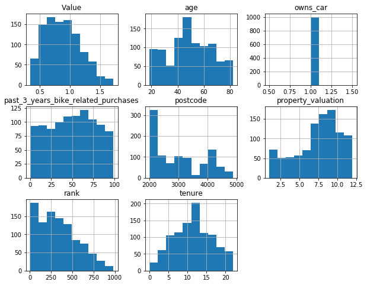

```python
#checking histogram of entite kpmg dataset
kpmg_n.hist(figsize=(10,8));
```

```python
#I am converting numerical variable to categorical variable using pandas' cut function
kpmg_n['ageGroup']=pd.cut(kpmg_n.age,[18,25,35,60,125],labels=['young adults', 'adults', 'middle aged', 'old adults'])
kpmg_n['ageGroup'].head()
```

```
0    young adults
1    young adults
2    young adults
3    young adults
4    young adults
Name: ageGroup, dtype: category
Categories (4, object): [young adults < adults < middle aged < old adults]
```

**BAR CHART OF QUALITATIVE VARIABLE IN THE KPMG NEW CUSTOMER DATASET**

```python
#Checking the overall counts of customers age categorising them into age groups in the dataset
pd.DataFrame(kpmg_n.ageGroup.value_counts())
```

|  | ageGroup |
| --- | --- |
| middle aged | 493 |
| old adults | 286 |
| adults | 124 |
| young adults | 97 |

[figure not shown]

```python
#Plotting the age Group on a bar chart
plt.figure(figsize=(10,4))
plt.subplot(1,2,1);
kpmg_n.ageGroup.value_counts().plot(kind='bar',color=['C4','C5','C6','C7']);
plt.title('Age group of new customer',fontsize=18)
plt.xlabel('ageGoup',fontsize=18)
plt.ylabel('customers counts',fontsize=18);

plt.subplot(1,2,2);
ageGroup_values=[493,286,124,97]
ageGroup_labels=["middle aged","young adults","adults","old adults"]
plt.axis("equal")
plt.title("Pie chart showing the new customers ageGroup")
plt.pie(ageGroup_values,labels=ageGroup_labels,radius=1.0,autopct='%0.1f%%',shadow=True,explode=[0,0.1,0.1,0],wedgeprops={'edgecolor':'black'});
```

```python
#Checking number of customers that made an online order in the kpmg dataset
pd.DataFrame(kpmg_n.gender.value_counts())
```

|  | gender |
| --- | --- |
| Female | 513 |
| Male | 470 |
| U | 17 |

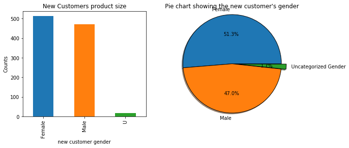

```python
plt.figure(figsize=(10,4))
plt.subplot(1,2,1)
kpmg_n.gender.value_counts().plot(kind='bar',title='New Customers product size',color=['C0','C1','C2']);
plt.xlabel('new customer gender')
plt.ylabel('Counts');

plt.subplot(1,2,2)
gen_values=[513,470,17]
gen_labels=["Female","Male","Uncategorized Gender"]
plt.axis("equal")
plt.title("Pie chart showing the new customer's gender")
plt.pie(gen_values,labels=gen_labels,radius=1.0,autopct='%0.1f%%',shadow=True,explode=[0,0,0.1],wedgeprops={'edgecolor':'black'});
```

```python
#Checking number of customers industry in the kpmg dataset
pd.DataFrame(kpmg_n.job_industry_category.value_counts())
```

|  | job_industry_category |
| --- | --- |
| Financial Services | 203 |
| Manufacturing | 199 |
| Health | 152 |
| Retail | 78 |
| Property | 64 |
| IT | 51 |
| Entertainment | 37 |
| Argiculture | 26 |
| Telecommunications | 25 |

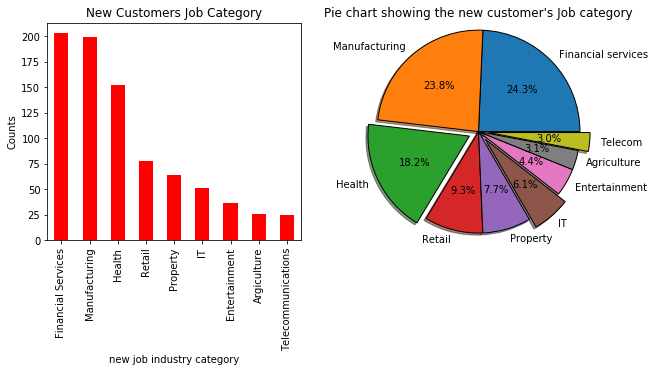

```python
plt.figure(figsize=(10,4))
plt.subplot(1,2,1)
kpmg_n.job_industry_category.value_counts().plot(kind='bar',title='New Customers Job Category',color=['red']);
plt.xlabel('new job industry category')
plt.ylabel('Counts');

plt.subplot(1,2,2)
ji_values=[203,199,152,78,64,51,37,26,25]
ji_labels=["Financial services","Manufacturing","Health","Retail","Property","IT","Entertainment","Agriculture","Telecom"]
plt.axis("equal")
plt.title("Pie chart showing the new customer's Job category")
plt.pie(ji_values,labels=ji_labels,radius=1.0,autopct='%0.1f%%',shadow=True,explode=[0,0,0.1,0,0,0.1,0,0,0.1],wedgeprops={'edgecolor':'black'});
```

```python
#Checking number of customers wealth in the kpmg dataset
pd.DataFrame(kpmg_n.wealth_segment.value_counts())
```

|  | wealth_segment |
| --- | --- |
| Mass Customer | 508 |
| High Net Worth | 251 |
| Affluent Customer | 241 |

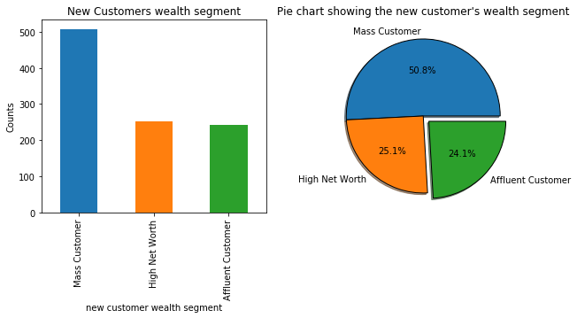

```python
plt.figure(figsize=(10,4))
plt.subplot(1,2,1)
kpmg_n.wealth_segment.value_counts().plot(kind='bar',title='New Customers wealth segment',color=['C0','C1','C2']);
plt.xlabel('new customer wealth segment')
plt.ylabel('Counts');

plt.subplot(1,2,2)
wealth_values=[508,251,241]
wealth_labels=["Mass Customer","High Net Worth","Affluent Customer"]
plt.axis("equal")
plt.title("Pie chart showing the new customer's wealth segment")
plt.pie(wealth_values,labels=wealth_labels,radius=1.0,autopct='%0.1f%%',shadow=True,explode=[0,0,0.1],wedgeprops={'edgecolor':'black'});
```

```python
#Checking number of customers wealth in the kpmg dataset
pd.DataFrame(kpmg_n.owns_car.value_counts())
```

|  | owns_car |
| --- | --- |
| True | 1000 |

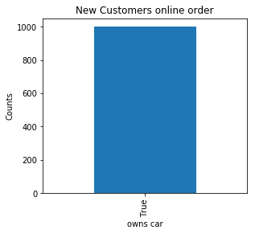

```python
plt.figure(figsize=(10,4))
plt.subplot(1,2,1)
kpmg_n.owns_car.value_counts().plot(kind='bar',title='New Customers online order',color=['C0','C1']);
plt.xlabel('owns car')
plt.ylabel('Counts');
```

## OLD CUSTOMERS VS NEW CUSTOMERS

**Showing relationships between varibales in the KPMG new and old customers dataset**

**(1) Gender vs Bike related purchase for the past 3 years**

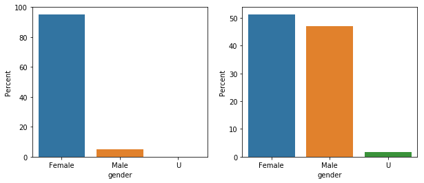

```python
plt.figure(figsize=(10,4))
plt.subplot(1,2,1);
ax = sb.barplot(x="gender", y="past_3_years_bike_related_purchases", data=kpmg, estimator=lambda x: len(x) / len(kpmg) * 100)
ax.set(ylabel="Percent");

plt.subplot(1,2,2);
ax = sb.barplot(x="gender", y="past_3_years_bike_related_purchases", data=kpmg_n, estimator=lambda x: len(x) / len(kpmg_n) * 100)
ax.set(ylabel="Percent");
```

**(2) Age Group Distribution**

[figure not shown]

```python
plt.figure(figsize=(10,4))
plt.subplot(1,2,1);
ageGroup_values=[493,286,124,97]
ageGroup_labels=["middle aged","young adults","adults","old adults"]
plt.axis("equal")
plt.title("Pie chart showing the new customers ageGroup")
plt.pie(ageGroup_values,labels=ageGroup_labels,radius=1.0,autopct='%0.1f%%',shadow=True,explode=[0,0.1,0.1,0],wedgeprops={'edgecolor':'black'});

plt.subplot(1,2,2);
ageGroup_values=[5848,5039,3201,2738]
ageGroup_labels=["middle aged","young adults","adults","old adults"]
plt.axis("equal")
plt.title("Pie chart showing the customers ageGroup")
plt.pie(ageGroup_values,labels=ageGroup_labels,radius=1.0,autopct='%0.1f%%',shadow=True,explode=[0,0.1,0.1,0],wedgeprops={'edgecolor':'black'});
```

**(3) JOB INDUSTRY DISTRIBUTION**

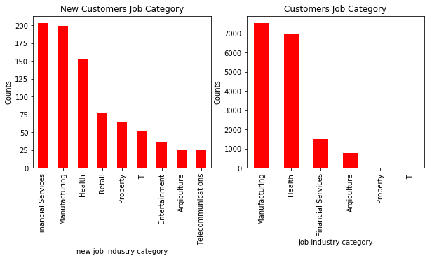

```python
plt.figure(figsize=(10,4))
plt.subplot(1,2,1)
kpmg_n.job_industry_category.value_counts().plot(kind='bar',title='New Customers Job Category',color=['red']);
plt.xlabel('new job industry category')
plt.ylabel('Counts');


plt.subplot(1,2,2)
kpmg.job_industry_category.value_counts().plot(kind='bar',title='Customers Job Category',color=['red']);
plt.xlabel('job industry category')
plt.ylabel('Counts');
```

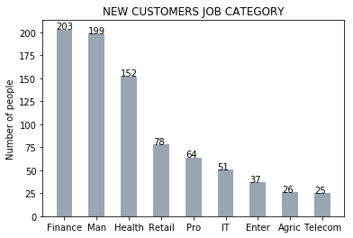

```python
#New customers job category
val=[203,199,152,78,64,51,37,26,25]
col=(0.2,0.3,0.4,0.5)
x=np.arange(9)
fig,ax=plt.subplots()
ax.set_ylabel('Number of people')
ax.set_title('NEW CUSTOMERS JOB CATEGORY')
plt.bar(x,val,color=col,width=0.5)

for i in range(len(val)):
    plt.text(x = i-0.25, y=val[i]+0.1, s=val[i], size = 10)

    plt.xticks(x,("Finance","Man","Health","Retail","Pro","IT","Enter","Agric","Telecom"))
```

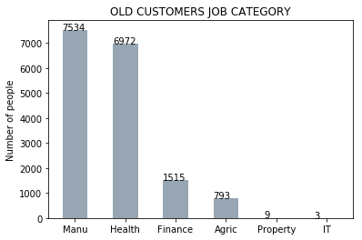

```python
val=[7534,6972,1515,793,9,3]
col=(0.2,0.3,0.4,0.5)
x2=np.arange(6)
fig2,ax2=plt.subplots()
ax2.set_ylabel('Number of people')
ax2.set_title('OLD CUSTOMERS JOB CATEGORY')
plt.bar(x2,val,color=col,width=0.5)

for i in range(len(val)):
    plt.text(x = i-0.25, y=val[i]+0.1, s=val[i], size = 10)

    plt.xticks(x2,("Manu","Health","Finance","Agric","Property","IT"))
```

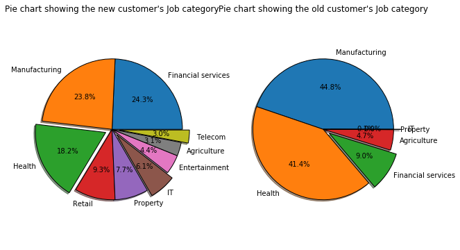

```python
plt.figure(figsize=(10,6))
plt.subplot(1,2,1)
jin_values=[203,199,152,78,64,51,37,26,25]
jin_labels=["Financial services","Manufacturing","Health","Retail","Property","IT","Entertainment","Agriculture","Telecom"]

plt.axis("equal")
plt.title("Pie chart showing the new customer's Job category")
plt.pie(jin_values,labels=jin_labels,radius=1.0,autopct='%0.1f%%',shadow=True,explode=[0,0,0.1,0,0,0.1,0,0,0.1],wedgeprops={'edgecolor':'black'});


plt.subplot(1,2,2)
jio_values=[7534,6972,1515,793,9,3]
jio_labels=["Manufacturing","Health","Financial services","Agriculture","Property","IT"]
plt.axis("equal")
plt.title("Pie chart showing the old customer's Job category")
plt.pie(jio_values,labels=jio_labels,radius=1.0,autopct='%0.1f%%',shadow=True,explode=[0,0,0.1,0,0,0.1],wedgeprops={'edgecolor':'black'});
```

**(4) Numbers of cars owned and not owned by state**

```python
byc=kpmg.groupby("state").owns_car.value_counts()
byc
```

```
state  owns_car
NSW    Yes         5754
       No          3200
QLD    Yes         2322
       No          1290
VIC    Yes         2893
       No          1367
Name: owns_car, dtype: int64
```

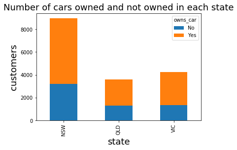

```python
#plotting stacked bar chart of state vs own cars by old customers
byc.unstack().plot(kind='bar',stacked=True);
plt.title('Number of cars owned and not owned in each state',fontsize=18)
plt.xlabel('state',fontsize=18)
plt.ylabel('customers',fontsize=18);
```

```python
byd=kpmg_n.groupby("state").owns_car.value_counts()
byd
```

```
state  owns_car
NSW    True        506
QLD    True        228
VIC    True        266
Name: owns_car, dtype: int64
```

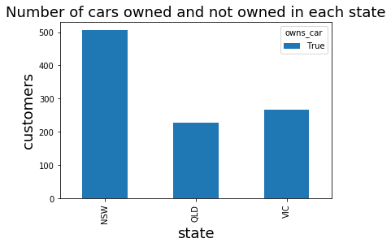

```python
byd.unstack().plot(kind='bar',stacked=True);
plt.title('Number of cars owned and not owned in each state',fontsize=18)
plt.xlabel('state',fontsize=18)
plt.ylabel('customers',fontsize=18);
```

**(5) Wealth segment by Age category**

```python
byy=kpmg.groupby("wealth_segment").ageGroup.value_counts()
byy
```

```
wealth_segment     ageGroup
Affluent Customer  old adults         9
High Net Worth     middle aged     5848
                   adults          1700
                   old adults         3
Mass Customer      young adults    5039
                   old adults      2726
                   adults          1501
Name: ageGroup, dtype: int64
```

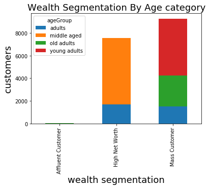

```python
#plotting stacked bar chart of state vs own cars by old customers
byy.unstack().plot(kind='bar',stacked=True);
plt.title('Wealth Segmentation By Age category',fontsize=18)
plt.xlabel('wealth segmentation',fontsize=18)
plt.ylabel('customers',fontsize=18);
```

```python
byz=kpmg_n.groupby("wealth_segment").ageGroup.value_counts()
byz
```

```
wealth_segment     ageGroup
Affluent Customer  middle aged     120
                   old adults       66
                   young adults     30
                   adults           25
High Net Worth     middle aged     120
                   old adults       72
                   adults           39
                   young adults     20
Mass Customer      middle aged     253
                   old adults      148
                   adults           60
                   young adults     47
Name: ageGroup, dtype: int64
```

```
Text(0,0.5,'customers')
```

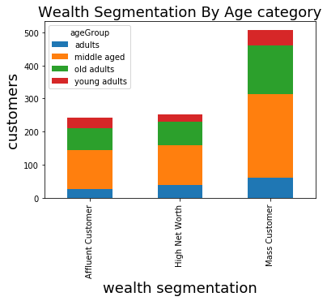

```python
#plotting stacked bar chart of state vs own cars by old customers
byz.unstack().plot(kind='bar',stacked=True);
plt.title('Wealth Segmentation By Age category',fontsize=18)
plt.xlabel('wealth segmentation',fontsize=18)
plt.ylabel('customers',fontsize=18)
```

## MODEL DEVELOPMENT

**(1) Using the full old customer for the model**

```python
kpmg.drop(['transaction_id'],axis=1,inplace=True)
kpmg.dtypes
```

```
product_id                                      int64
customer_id                                     int64
recency                                         int64
transaction_date                       datetime64[ns]
transaction_month                              object
online_order                                     bool
order_status                                 category
brand                                        category
product_line                                 category
product_class                                category
product_size                                 category
list_price                                    float64
standard_cost                                 float64
product_first_sold_date                datetime64[ns]
profit                                        float64
gender                                       category
past_3_years_bike_related_purchases             int64
dob                                            object
age                                           float64
job_title                                    category
job_industry_category                        category
wealth_segment                               category
deceased_indicator                             object
owns_car                                     category
tenure                                          int64
address                                        object
postcode                                        int64
state                                          object
country                                        object
property_valuation                              int64
ageGroup                                     category
dtype: object
```

```python
kpmg.head(5)
```

|  | product_id | customer_id | recency | transaction_date | transaction_month | online_order | order_status | brand | product_line | product_class | ... | wealth_segment | deceased_indicator | owns_car | tenure | address | postcode | state | country | property_valuation | ageGroup |
| --- | --- | --- | --- | --- | --- | --- | --- | --- | --- | --- | --- | --- | --- | --- | --- | --- | --- | --- | --- | --- | --- |
| 0 | 2 | 3123 | 0 | 2017-12-30 | December | False | Approved | Giant Bicycles | Road | low | ... | Mass Customer | N | Yes | 1 | 6915 Nobel Crossing | 2195 | NSW | Australia | 6 | young adults |
| 1 | 62 | 3355 | 0 | 2017-12-30 | December | False | Approved | Solex | Standard | medium | ... | Mass Customer | N | Yes | 1 | 45 Talisman Pass | 4102 | QLD | Australia | 4 | young adults |
| 2 | 62 | 1854 | 0 | 2017-12-30 | December | True | Approved | Solex | Standard | high | ... | High Net Worth | N | No | 12 | 48023 International Way | 3630 | VIC | Australia | 1 | middle aged |
| 3 | 70 | 2878 | 0 | 2017-12-30 | December | False | Approved | Trek Bicycles | Standard | high | ... | Mass Customer | N | Yes | 1 | 12574 Truax Alley | 2316 | NSW | Australia | 6 | young adults |
| 4 | 80 | 2865 | 0 | 2017-12-30 | December | True | Approved | Trek Bicycles | Standard | medium | ... | Mass Customer | N | Yes | 1 | 6804 Red Cloud Parkway | 2099 | NSW | Australia | 9 | young adults |

5 rows × 31 columns

```python
gen=pd.get_dummies (kpmg["gender"],drop_first=True)
gen.head(2)
```

|  | Male | U |
| --- | --- | --- |
| 0 | 0 | 0 |
| 1 | 0 | 0 |

```python
order=pd.get_dummies (kpmg["order_status"],drop_first=True)
order.head(2)
```

|  | Cancelled |
| --- | --- |
| 0 | 0 |
| 1 | 0 |

```python
brand=pd.get_dummies (kpmg["brand"],drop_first=True)
brand.head(2)
```

|  | Norco Bicycles | OHM Cycles | Solex | Trek Bicycles | WeareA2B |
| --- | --- | --- | --- | --- | --- |
| 0 | 0 | 0 | 0 | 0 | 0 |
| 1 | 0 | 0 | 1 | 0 | 0 |

```python
pl=pd.get_dummies (kpmg["product_line"],drop_first=True)
pl.head(2)
```

|  | Road | Standard | Touring |
| --- | --- | --- | --- |
| 0 | 1 | 0 | 0 |
| 1 | 0 | 1 | 0 |

```python
pc=pd.get_dummies (kpmg["product_class"],drop_first=True)
pc.head(2)
```

|  | low | medium |
| --- | --- | --- |
| 0 | 1 | 0 |
| 1 | 0 | 1 |

```python
ps=pd.get_dummies (kpmg["product_size"],drop_first=True)
ps.head(2)
```

|  | medium | small |
| --- | --- | --- |
| 0 | 0 | 1 |
| 1 | 1 | 0 |

```python
age=pd.get_dummies (kpmg["ageGroup"],drop_first=True)
age.head(2)
```

|  | adults | middle aged | old adults |
| --- | --- | --- | --- |
| 0 | 0 | 0 | 0 |
| 1 | 0 | 0 | 0 |

```python
jobt=pd.get_dummies (kpmg["job_title"],drop_first=True)
jobt.head(2)
```

|  | Executive Secretary | Food Chemist | Human Resources Assistant II | Internal Auditor | Operator | Payment Adjustment Coordinator | Recruiter | Research Associate | Speech Pathologist |
| --- | --- | --- | --- | --- | --- | --- | --- | --- | --- |
| 0 | 0 | 1 | 0 | 0 | 0 | 0 | 0 | 0 | 0 |
| 1 | 0 | 1 | 0 | 0 | 0 | 0 | 0 | 0 | 0 |

```python
jic=pd.get_dummies (kpmg["job_industry_category"],drop_first=True)
jic.head(2)
```

|  | Financial Services | Health | IT | Manufacturing | Property |
| --- | --- | --- | --- | --- | --- |
| 0 | 0 | 1 | 0 | 0 | 0 |
| 1 | 0 | 1 | 0 | 0 | 0 |

```python
wealth=pd.get_dummies (kpmg["wealth_segment"],drop_first=True)
wealth.head(2)
```

|  | High Net Worth | Mass Customer |
| --- | --- | --- |
| 0 | 0 | 1 |
| 1 | 0 | 1 |

```python
kpmg=pd.concat([kpmg,gen,order,brand,pl,pc,ps,age,jobt,jic,wealth],axis=1)
kpmg.head(4)
```

|  | product_id | customer_id | recency | transaction_date | transaction_month | online_order | order_status | brand | product_line | product_class | ... | Recruiter | Research Associate | Speech Pathologist | Financial Services | Health | IT | Manufacturing | Property | High Net Worth | Mass Customer |
| --- | --- | --- | --- | --- | --- | --- | --- | --- | --- | --- | --- | --- | --- | --- | --- | --- | --- | --- | --- | --- | --- |
| 0 | 2 | 3123 | 0 | 2017-12-30 | December | False | Approved | Giant Bicycles | Road | low | ... | 0 | 0 | 0 | 0 | 1 | 0 | 0 | 0 | 0 | 1 |
| 1 | 62 | 3355 | 0 | 2017-12-30 | December | False | Approved | Solex | Standard | medium | ... | 0 | 0 | 0 | 0 | 1 | 0 | 0 | 0 | 0 | 1 |
| 2 | 62 | 1854 | 0 | 2017-12-30 | December | True | Approved | Solex | Standard | high | ... | 0 | 1 | 0 | 0 | 0 | 0 | 1 | 0 | 1 | 0 |
| 3 | 70 | 2878 | 0 | 2017-12-30 | December | False | Approved | Trek Bicycles | Standard | high | ... | 0 | 0 | 0 | 0 | 1 | 0 | 0 | 0 | 0 | 1 |

4 rows × 65 columns

```python
kpmg.drop(['product_id','customer_id','transaction_date','transaction_month','product_first_sold_date','dob','age','deceased_indicator','owns_car','address','postcode','state','country'],axis=1,inplace=True)
```

```python
kpmg.head(3)
```

|  | recency | online_order | order_status | brand | product_line | product_class | product_size | list_price | standard_cost | profit | ... | Recruiter | Research Associate | Speech Pathologist | Financial Services | Health | IT | Manufacturing | Property | High Net Worth | Mass Customer |
| --- | --- | --- | --- | --- | --- | --- | --- | --- | --- | --- | --- | --- | --- | --- | --- | --- | --- | --- | --- | --- | --- |
| 0 | 0 | False | Approved | Giant Bicycles | Road | low | small | 590.26 | 525.33 | 64.93 | ... | 0 | 0 | 0 | 0 | 1 | 0 | 0 | 0 | 0 | 1 |
| 1 | 0 | False | Approved | Solex | Standard | medium | medium | 478.16 | 298.72 | 179.44 | ... | 0 | 0 | 0 | 0 | 1 | 0 | 0 | 0 | 0 | 1 |
| 2 | 0 | True | Approved | Solex | Standard | high | medium | 1024.66 | 614.80 | 409.86 | ... | 0 | 1 | 0 | 0 | 0 | 0 | 1 | 0 | 1 | 0 |

3 rows × 52 columns

```python
kpmg.dtypes
```

```
recency                                   int64
online_order                               bool
order_status                           category
brand                                  category
product_line                           category
product_class                          category
product_size                           category
list_price                              float64
standard_cost                           float64
profit                                  float64
gender                                 category
past_3_years_bike_related_purchases       int64
job_title                              category
job_industry_category                  category
wealth_segment                         category
tenure                                    int64
property_valuation                        int64
ageGroup                               category
Male                                      uint8
U                                         uint8
Cancelled                                 uint8
Norco Bicycles                            uint8
OHM Cycles                                uint8
Solex                                     uint8
Trek Bicycles                             uint8
WeareA2B                                  uint8
Road                                      uint8
Standard                                  uint8
Touring                                   uint8
low                                       uint8
medium                                    uint8
medium                                    uint8
small                                     uint8
adults                                    uint8
middle aged                               uint8
old adults                                uint8
Executive Secretary                       uint8
Food Chemist                              uint8
Human Resources Assistant II              uint8
Internal Auditor                          uint8
Operator                                  uint8
Payment Adjustment Coordinator            uint8
Recruiter                                 uint8
Research Associate                        uint8
Speech Pathologist                        uint8
Financial Services                        uint8
Health                                    uint8
IT                                        uint8
Manufacturing                             uint8
Property                                  uint8
High Net Worth                            uint8
Mass Customer                             uint8
dtype: object
```

```python
##Drop the initial columns of the dummy variable
kpmg.drop(['gender','order_status','brand','product_line','product_class','product_size','ageGroup','job_title','job_industry_category','wealth_segment'],axis=1,inplace=True)
```

```python
X=kpmg.drop("online_order",axis=1)

y=kpmg['online_order']
```

```python
from sklearn.cross_validation import train_test_split
```

```python
X_train,X_test,y_train,y_test=train_test_split(X,y,test_size=0.3,random_state=1)
```

```python
import statsmodels.api as sm
logit_model=sm.Logit(y,X)
result=logit_model.fit()
print(result.summary2())
```

```
Warning: Maximum number of iterations has been exceeded.
         Current function value: 0.692235
         Iterations: 35
                                           Results: Logit
=====================================================================================================
Model:                          Logit                        No. Iterations:               35.0000
Dependent Variable:             online_order                 Pseudo R-squared:             0.001
Date:                           2020-08-26 09:52             AIC:                          23349.0778
No. Observations:               16826                        BIC:                          23557.8062
Df Model:                       26                           Log-Likelihood:               -11648.
Df Residuals:                   16799                        LL-Null:                      -11663.
Converged:                      0.0000                       Scale:                        1.0000
-----------------------------------------------------------------------------------------------------
                                     Coef.     Std.Err.      z    P>|z|      [0.025         0.975]
-----------------------------------------------------------------------------------------------------
recency                             -0.0001        0.0001 -0.5621 0.5741        -0.0004        0.0002
list_price                          -0.0021      524.4174 -0.0000 1.0000     -1027.8413     1027.8370
standard_cost                        0.0021      524.4174  0.0000 1.0000     -1027.8370     1027.8413
profit                               0.0022      524.4174  0.0000 1.0000     -1027.8370     1027.8413
past_3_years_bike_related_purchases  0.0044    11508.5606  0.0000 1.0000    -22556.3598    22556.3686
tenure                               0.0322    33148.1427  0.0000 1.0000    -64969.1337    64969.1981
property_valuation                  -0.0000        0.0055 -0.0076 0.9939        -0.0107        0.0107
Male                                 0.0421           nan     nan    nan            nan           nan
U                                   -0.3202           nan     nan    nan            nan           nan
Cancelled                            0.3965        0.1657  2.3937 0.0167         0.0718        0.7212
Norco Bicycles                      -0.0878        0.0574 -1.5303 0.1260        -0.2002        0.0246
OHM Cycles                           0.0280        0.0572  0.4891 0.6248        -0.0842        0.1402
Solex                               -0.0768        0.0516 -1.4882 0.1367        -0.1780        0.0244
Trek Bicycles                       -0.0394        0.0578 -0.6807 0.4961        -0.1527        0.0740
WeareA2B                            -0.0499        0.0595 -0.8373 0.4024        -0.1665        0.0668
Road                                -0.0062        0.1184 -0.0522 0.9584        -0.2382        0.2258
Standard                            -0.0508        0.1175 -0.4325 0.6654        -0.2812        0.1795
Touring                              0.0028        0.1367  0.0201 0.9839        -0.2652        0.2707
low                                 -0.0062        0.0625 -0.0997 0.9206        -0.1287        0.1163
medium                              -0.0675        0.0470 -1.4343 0.1515        -0.1597        0.0247
medium                               0.0465        0.0469  0.9910 0.3217        -0.0455        0.1384
small                                0.1006        0.0739  1.3615 0.1734        -0.0442        0.2453
adults                               0.1230  1905337.0578  0.0000 1.0000  -3734391.8886  3734392.1347
middle aged                         -0.1367  2658505.8059 -0.0000 1.0000  -5210575.7689  5210575.4956
old adults                          -0.3333           nan     nan    nan            nan           nan
Executive Secretary                 -0.0710  1762833.2388 -0.0000 1.0000  -3455089.7299  3455089.5879
Food Chemist                         0.0687  3080364.4308  0.0000 1.0000  -6037403.2748  6037403.4123
Human Resources Assistant II         0.7123  7785057.0689  0.0000 1.0000 -15258430.7603 15258432.1849
Internal Auditor                    -0.4115  6274794.3442 -0.0000 1.0000 -12298371.3365 12298370.5134
Operator                             0.1204           nan     nan    nan            nan           nan
Payment Adjustment Coordinator      -0.1777  1817123.9049 -0.0000 1.0000  -3561497.5868  3561497.2314
Recruiter                           -0.0625 48353385.4645 -0.0000 1.0000 -94770894.1035 94770893.9785
Research Associate                  -0.0584  1644138.9108 -0.0000 1.0000  -3222453.1092  3222452.9924
Speech Pathologist                  -0.0783 11660857.2316 -0.0000 1.0000 -22854860.2811 22854860.1246
Financial Services                   0.2225  8386669.8072  0.0000 1.0000 -16437570.5498 16437570.9947
Health                              -0.0023  1742821.4373 -0.0000 1.0000  -3415867.2509  3415867.2464
IT                                  -0.3202           nan     nan    nan            nan           nan
Manufacturing                       -0.2361           nan     nan    nan            nan           nan
Property                            -0.0625 48082914.8890 -0.0000 1.0000 -94240781.5167 94240781.3917
High Net Worth                       0.0777           nan     nan    nan            nan           nan
Mass Customer                       -0.2934  1848944.9685 -0.0000 1.0000  -3623865.8411  3623865.2543
=====================================================================================================
```

```python
#checking the logistic model coefficient
result.params
```

```
recency                               -0.000082
list_price                            -0.002146
standard_cost                          0.002121
profit                                 0.002164
past_3_years_bike_related_purchases    0.004385
tenure                                 0.032182
property_valuation                    -0.000042
Male                                   0.042143
U                                     -0.320180
Cancelled                              0.396525
Norco Bicycles                        -0.087785
OHM Cycles                             0.027996
Solex                                 -0.076838
Trek Bicycles                         -0.039356
WeareA2B                              -0.049851
Road                                  -0.006181
Standard                              -0.050821
Touring                                0.002752
low                                   -0.006230
medium                                -0.067472
medium                                 0.046484
small                                  0.100552
adults                                 0.123028
middle aged                           -0.136676
old adults                            -0.333282
Executive Secretary                   -0.070993
Food Chemist                           0.068735
Human Resources Assistant II           0.712263
Internal Auditor                      -0.411538
Operator                               0.120394
Payment Adjustment Coordinator        -0.177696
Recruiter                             -0.062503
Research Associate                    -0.058424
Speech Pathologist                    -0.078251
Financial Services                     0.222474
Health                                -0.002258
IT                                    -0.320179
Manufacturing                         -0.236122
Property                              -0.062503
High Net Worth                         0.077710
Mass Customer                         -0.293403
dtype: float64
```

```python
#Exponentiate the coefficients to get the log odds
np.exp(result.params)
```

```
recency                                0.999918
list_price                             0.997857
standard_cost                          1.002123
profit                                 1.002166
past_3_years_bike_related_purchases    1.004394
tenure                                 1.032706
property_valuation                     0.999958
Male                                   1.043043
U                                      0.726018
Cancelled                              1.486649
Norco Bicycles                         0.915958
OHM Cycles                             1.028392
Solex                                  0.926040
Trek Bicycles                          0.961408
WeareA2B                               0.951371
Road                                   0.993838
Standard                               0.950448
Touring                                1.002756
low                                    0.993789
medium                                 0.934754
medium                                 1.047581
small                                  1.105781
adults                                 1.130916
middle aged                            0.872253
old adults                             0.716568
Executive Secretary                    0.931468
Food Chemist                           1.071153
Human Resources Assistant II           2.038599
Internal Auditor                       0.662630
Operator                               1.127941
Payment Adjustment Coordinator         0.837197
Recruiter                              0.939410
Research Associate                     0.943250
Speech Pathologist                     0.924732
Financial Services                     1.249163
Health                                 0.997745
IT                                     0.726019
Manufacturing                          0.789684
Property                               0.939410
High Net Worth                         1.080809
Mass Customer                          0.745722
dtype: float64
```

```python
#Checking if variables are significant with their pvalues
result.pvalues
```

```
recency                                0.574075
list_price                             0.999997
standard_cost                          0.999997
profit                                 0.999997
past_3_years_bike_related_purchases    1.000000
tenure                                 0.999999
property_valuation                     0.993897
Male                                        NaN
U                                           NaN
Cancelled                              0.016679
Norco Bicycles                         0.125950
OHM Cycles                             0.624755
Solex                                  0.136700
Trek Bicycles                          0.496063
WeareA2B                               0.402435
Road                                   0.958352
Standard                               0.665413
Touring                                0.983937
low                                    0.920591
medium                                 0.151495
medium                                 0.321696
small                                  0.173351
adults                                 1.000000
middle aged                            1.000000
old adults                                  NaN
Executive Secretary                    1.000000
Food Chemist                           1.000000
Human Resources Assistant II           1.000000
Internal Auditor                       1.000000
Operator                                    NaN
Payment Adjustment Coordinator         1.000000
Recruiter                              1.000000
Research Associate                     1.000000
Speech Pathologist                     1.000000
Financial Services                     1.000000
Health                                 1.000000
IT                                          NaN
Manufacturing                               NaN
Property                               1.000000
High Net Worth                              NaN
Mass Customer                          1.000000
dtype: float64
```

```python
# odds ratios and 95% CI
params = result.params
conf = result.conf_int()
conf['OR'] = params
conf.columns = ['2.5%', '97.5%', 'OR']
np.exp(conf)
```

|  | 2.5% | 97.5% | OR |
| --- | --- | --- | --- |
| recency | 0.999630 | 1.000205 | 0.999918 |
| list_price | 0.000000 | inf | 0.997857 |
| standard_cost | 0.000000 | inf | 1.002123 |
| profit | 0.000000 | inf | 1.002166 |
| past_3_years_bike_related_purchases | 0.000000 | inf | 1.004394 |
| tenure | 0.000000 | inf | 1.032706 |
| property_valuation | 0.989314 | 1.010717 | 0.999958 |
| Male | NaN | NaN | 1.043043 |
| U | NaN | NaN | 0.726018 |
| Cancelled | 1.074494 | 2.056899 | 1.486649 |
| Norco Bicycles | 0.818551 | 1.024956 | 0.915958 |
| OHM Cycles | 0.919259 | 1.150481 | 1.028392 |
| Solex | 0.836914 | 1.024657 | 0.926040 |
| Trek Bicycles | 0.858408 | 1.076768 | 0.961408 |
| WeareA2B | 0.846584 | 1.069128 | 0.951371 |
| Road | 0.788081 | 1.253317 | 0.993838 |
| Standard | 0.754912 | 1.196633 | 0.950448 |
| Touring | 0.767075 | 1.310849 | 1.002756 |
| low | 0.879221 | 1.123287 | 0.993789 |
| medium | 0.852421 | 1.025039 | 0.934754 |
| medium | 0.955565 | 1.148459 | 1.047581 |
| small | 0.956765 | 1.278005 | 1.105781 |
| adults | 0.000000 | inf | 1.130916 |
| middle aged | 0.000000 | inf | 0.872253 |
| old adults | NaN | NaN | 0.716568 |
| Executive Secretary | 0.000000 | inf | 0.931468 |
| Food Chemist | 0.000000 | inf | 1.071153 |
| Human Resources Assistant II | 0.000000 | inf | 2.038599 |
| Internal Auditor | 0.000000 | inf | 0.662630 |
| Operator | NaN | NaN | 1.127941 |
| Payment Adjustment Coordinator | 0.000000 | inf | 0.837197 |
| Recruiter | 0.000000 | inf | 0.939410 |
| Research Associate | 0.000000 | inf | 0.943250 |
| Speech Pathologist | 0.000000 | inf | 0.924732 |
| Financial Services | 0.000000 | inf | 1.249163 |
| Health | 0.000000 | inf | 0.997745 |
| IT | NaN | NaN | 0.726019 |
| Manufacturing | NaN | NaN | 0.789684 |
| Property | 0.000000 | inf | 0.939410 |
| High Net Worth | NaN | NaN | 1.080809 |
| Mass Customer | 0.000000 | inf | 0.745722 |

```python
from sklearn.linear_model import LogisticRegression
logmodel=LogisticRegression()
logmodel.fit(X_train,y_train)
```

```
LogisticRegression(C=1.0, class_weight=None, dual=False, fit_intercept=True,
          intercept_scaling=1, max_iter=100, multi_class='ovr', n_jobs=1,
          penalty='l2', random_state=None, solver='liblinear', tol=0.0001,
          verbose=0, warm_start=False)
```

**Predicting the test set results and calculating the accuracy**

```python
y_pred = logmodel.predict(X_test)
print('Accuracy of logistic regression classifier on test set: {:.2f}'.format(logmodel.score(X_test, y_test)))
```

```
Accuracy of logistic regression classifier on test set: 0.50
```

**Confusion Matrix**

```python
from sklearn.metrics import confusion_matrix
confusion_matrix = confusion_matrix(y_test, y_pred)
print(confusion_matrix)
```

```
[[1368 1161]
 [1375 1144]]
```

```
Text(0.5,257.44,'Predicted label')
```

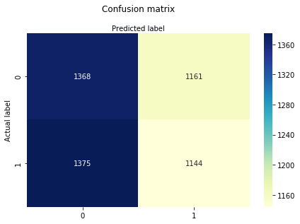

```python
class_names=[0,1] # name  of classes
fig, ax = plt.subplots()
tick_marks = np.arange(len(class_names))
plt.xticks(tick_marks, class_names)
plt.yticks(tick_marks, class_names)
# create heatmap
sb.heatmap(pd.DataFrame(confusion_matrix), annot=True, cmap="YlGnBu" ,fmt='g')
ax.xaxis.set_label_position("top")
plt.tight_layout()
plt.title('Confusion matrix', y=1.1)
plt.ylabel('Actual label')
plt.xlabel('Predicted label')
```

**The result is telling us that we have 1368+1144 correct predictions and 1161+1375 incorrect predictions.**

**Compute precision, recall, F-measure and support**

```python
# import the metrics class
from sklearn import metrics
```

```python
print("Accuracy:",metrics.accuracy_score(y_test, y_pred))
print("Precision:",metrics.precision_score(y_test, y_pred))
print("Recall:",metrics.recall_score(y_test, y_pred))
```

```
Accuracy: 0.497622820919
Precision: 0.496312364425
Recall: 0.454148471616
```

```python
from sklearn.metrics import classification_report
print(classification_report(y_test, y_pred))
```

```
             precision    recall  f1-score   support

      False       0.50      0.54      0.52      2529
       True       0.50      0.45      0.47      2519

avg / total       0.50      0.50      0.50      5048
```

**ROC Curve**

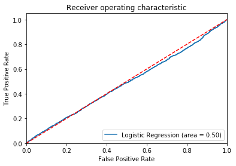

```python
from sklearn.metrics import roc_auc_score
from sklearn.metrics import roc_curve
logit_roc_auc = roc_auc_score(y_test, logmodel.predict(X_test))
fpr, tpr, thresholds = roc_curve(y_test, logmodel.predict_proba(X_test)[:,1])
plt.figure()
plt.plot(fpr, tpr, label='Logistic Regression (area = %0.2f)' % logit_roc_auc)
plt.plot([0, 1], [0, 1],'r--')
plt.xlim([0.0, 1.0])
plt.ylim([0.0, 1.05])
plt.xlabel('False Positive Rate')
plt.ylabel('True Positive Rate')
plt.title('Receiver operating characteristic')
plt.legend(loc="lower right")
plt.savefig('Log_ROC')
plt.show()
```

The receiver operating characteristic (ROC) curve is another common tool used with binary classifiers. The dotted line represents the ROC curve of a purely random classifier; a good classifier stays as far away from that line as possible (toward the top-left corner).